# STAT 440: House Prices Modelling

Team: Yifan(Lucas) Wu; Kaggle Team Name: ‘Let’s go 440’

September 27, 2016

## Introduction

We are given a data science competition, House Prices: Advanced Regression Techniques, from Kaggle. With 79 explanatory variables describing (almost) every aspect of residential homes in Ames, Iowa, this competition challenges us to predict the final price of each home. More info can be found at: https://www.kaggle.com/c/house-prices-advanced-regression-techniques

#### Load in and explore data

```r
house_prices_data <- read.csv('data/train.csv', stringsAsFactors = FALSE)
house_prices_data_test <- read.csv('data/test.csv', stringsAsFactors = FALSE)
```

The training data set of housing consists of 1460 rows and 81 columns.

## Method 1: Stepwise Regression

#### Standing on the Shoulder of Giants

Credits to the idea of Sung Ha which scored 0.12794 on Kaggle’s leaderboard! However, the stepwise method has a major drawback which requires us to convert all the categorical variables into numerical variables to fix the problem of unseen level in the test set.

```r
train_sung <- house_prices_data %>% mutate_if(is.character, as.factor)

n_na <-sapply(train_sung,function(y)length(which(is.na(y)==T)))
n_na.df<- data.frame(var=colnames(train_sung),num_NA=n_na)

train_sung <- train_sung[,!(names(train_sung)%in%c("Id","Alley","PoolQC","Fence","MiscFeature"))]

num<-sapply(train_sung,is.numeric)
num<-train_sung[,num]

for(i in 1:76){
  if(is.factor(train_sung[,i])){
    train_sung[,i]<-as.integer(train_sung[,i])
  }
}
train_sung[is.na(train_sung)]<-0
num[is.na(num)]<-0

train.train<- train_sung[1:floor(length(train_sung[,1])*0.8),]
train.train$SalePrice <- log(train.train$SalePrice)
train.test<- train_sung[(length(train.train[,1])+1):1460,]
train.test$SalePrice <- log(train.test$SalePrice)

lm.train.train <- lm(SalePrice~.,train.train)
# summary(lm.train.train)
step.lm.train.train <- step(lm.train.train,trace = 0)
# summary(step.lm.train.train)
lm.train.train <- lm(SalePrice~.,step.lm.train.train$model)
# plot(lm.train.train)

# Load and predict on test set
test_sung <- house_prices_data_test %>% mutate_if(is.character, as.factor)

n_na <-sapply(test_sung,function(y)length(which(is.na(y)==T)))
n_na.df<- data.frame(var=colnames(test_sung),num_NA=n_na)

test_sung <- test_sung[,!(names(test_sung)%in%c("Id","Alley","PoolQC","Fence","MiscFeature"))]

num<-sapply(test_sung,is.numeric)
num<-test_sung[,num]

for(i in 1:75){
  if(is.factor(test_sung[,i])){
    test_sung[,i]<-as.integer(test_sung[,i])
  }
}
test_sung[is.na(test_sung)]<-0
num[is.na(num)]<-0

sung.predicted_values <- exp(predict(lm.train.train, newdata = test_sung))
```

#### Validation

LOOCV for the stepwise model.

```r
# leave-one-out cross-validation
out_of_sample_prediction <- rep(NA, nrow(train_sung))
train_sung$SalePrice <- log(train_sung$SalePrice)
for(data_point in 1:nrow(train_sung)){
  # Fit model on data with point left out
  # lm_model_loo <- lm(SalePrice ~ OverallQual + GrLivArea , data = train[-data_point, ])
  out_of_sample_prediction[data_point] <- (predict(lm.train.train, newdata = train_sung[data_point, ]))
}
```

```r
out_of_sample_prediction[out_of_sample_prediction < 0] <- 100
eval_metric(out_of_sample_prediction, house_prices_data$SalePrice)
```

```
## [1] 0.1429511
```

## Method 2: Shrinkage Methods

A pretty good result from stepwise regression indicates that there should be room for improvement by employing regularized regression such as Ridge Regression or LASSO.

## Explorary Data Analysis

```r
house_prices_data_test$SalePrice <- -999
full <- rbind(house_prices_data,house_prices_data_test)

full <- full %>% mutate_if(is.character, as.factor)

factor_columns <- names(which(sapply(full, class) == 'factor'))

non_factor_columns <- names(which(sapply(full, class) != 'factor'))
non_factor_columns <- non_factor_columns[!non_factor_columns %in% c("Id","SalePrice")]
```

If we take a look at the missing values in this data set, there are 6965 missing values in the training set and 7000 in the test set.

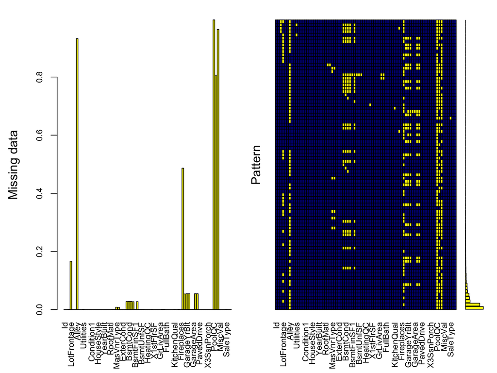

```r
# display the pattern of missing values
mice_plot <- aggr(full, col=c('navyblue','yellow'),
                  numbers=T, sortVars=F,
                  labels=names(full), cex.axis=.8,
                  gap=3, ylab=c("Missing data","Pattern"))
```

We can further investigate how many missing values in each column in the training set and test set:

```r
missing_full <- sapply(full, function(x) sum(is.na(x)))
missing_full[missing_full!=0]
```

```
##     MSZoning  LotFrontage        Alley    Utilities  Exterior1st
##            4          486         2721            2            1
##  Exterior2nd   MasVnrType   MasVnrArea     BsmtQual     BsmtCond
##            1           24           23           81           82
## BsmtExposure BsmtFinType1   BsmtFinSF1 BsmtFinType2   BsmtFinSF2
##           82           79            1           80            1
##    BsmtUnfSF  TotalBsmtSF   Electrical BsmtFullBath BsmtHalfBath
##            1            1            1            2            2
##  KitchenQual   Functional  FireplaceQu   GarageType  GarageYrBlt
##            1            2         1420          157          159
## GarageFinish   GarageCars   GarageArea   GarageQual   GarageCond
##          159            1            1          159          159
##       PoolQC        Fence  MiscFeature     SaleType
##         2909         2348         2814            1
```

Correlation plot

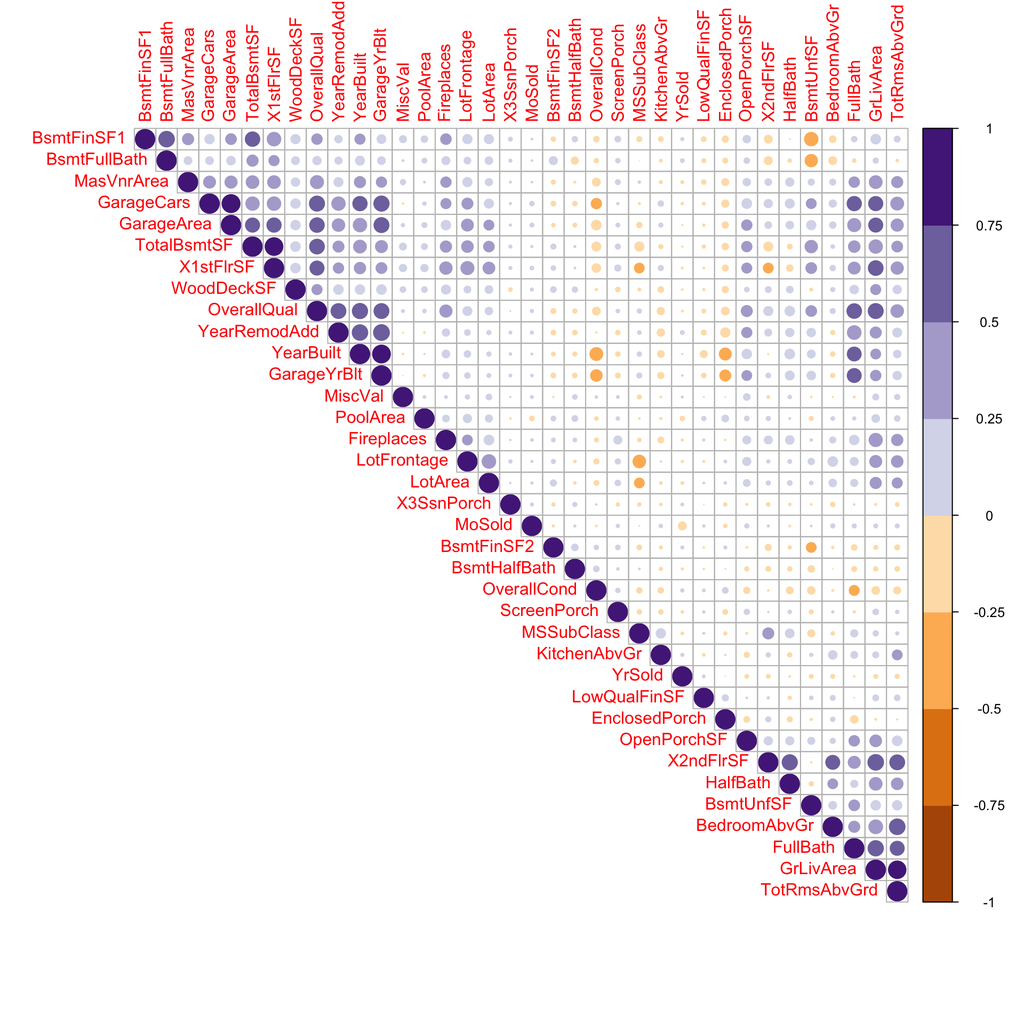

```r
M<-cor(na.omit(full[non_factor_columns]))
corrplot(M, type="upper", order="hclust",col=brewer.pal(n=8, name="PuOr"))
```

## Feature Engineering

```r
house_prices_data <- read.csv('data/train.csv', stringsAsFactors = FALSE)
house_prices_data_test <- read.csv('data/test.csv', stringsAsFactors = FALSE)
house_prices_data <- house_prices_data[-c(524,692,1183,1299), ]
house_prices_data_test$SalePrice <- -999
full <- rbind(house_prices_data,house_prices_data_test)

missing_full_after <- sapply(full, function(x) sum(is.na(x)))
missing_full_after[missing_full_after!=0]
```

```
##     MSZoning  LotFrontage        Alley    Utilities  Exterior1st
##            4          486         2717            2            1
##  Exterior2nd   MasVnrType   MasVnrArea     BsmtQual     BsmtCond
##            1           24           23           81           82
## BsmtExposure BsmtFinType1   BsmtFinSF1 BsmtFinType2   BsmtFinSF2
##           82           79            1           80            1
##    BsmtUnfSF  TotalBsmtSF   Electrical BsmtFullBath BsmtHalfBath
##            1            1            1            2            2
##  KitchenQual   Functional  FireplaceQu   GarageType  GarageYrBlt
##            1            2         1420          157          159
## GarageFinish   GarageCars   GarageArea   GarageQual   GarageCond
##          159            1            1          159          159
##       PoolQC        Fence  MiscFeature     SaleType
##         2907         2345         2810            1
```

```r
trainTest <- full
cat_var <- which(sapply( trainTest, class ) == "character")
trainTest[,cat_var] <- replace(trainTest[,cat_var],
                               is.na(trainTest[,cat_var]), 'miss')
# turn into factors
# trainTest[,cat_var] <- as.data.frame(unclass(trainTest[,cat_var]))
trainTest <- trainTest %>% mutate_if(is.character, as.factor)

factor_columns <- names(which(sapply(trainTest, class) == 'factor'))
factor_columns
```

```
##  [1] "MSZoning"      "Street"        "Alley"         "LotShape"
##  [5] "LandContour"   "Utilities"     "LotConfig"     "LandSlope"
##  [9] "Neighborhood"  "Condition1"    "Condition2"    "BldgType"
## [13] "HouseStyle"    "RoofStyle"     "RoofMatl"      "Exterior1st"
## [17] "Exterior2nd"   "MasVnrType"    "ExterQual"     "ExterCond"
## [21] "Foundation"    "BsmtQual"      "BsmtCond"      "BsmtExposure"
## [25] "BsmtFinType1"  "BsmtFinType2"  "Heating"       "HeatingQC"
## [29] "CentralAir"    "Electrical"    "KitchenQual"   "Functional"
## [33] "FireplaceQu"   "GarageType"    "GarageFinish"  "GarageQual"
## [37] "GarageCond"    "PavedDrive"    "PoolQC"        "Fence"
## [41] "MiscFeature"   "SaleType"      "SaleCondition"
```

```r
non_factor_columns <- names(which(sapply(trainTest, class) != 'factor'))
# get rid of Id
non_factor_columns <- non_factor_columns[!non_factor_columns %in% c("Id","SalePrice")]
non_factor_columns
```

```
##  [1] "MSSubClass"    "LotFrontage"   "LotArea"       "OverallQual"
##  [5] "OverallCond"   "YearBuilt"     "YearRemodAdd"  "MasVnrArea"
##  [9] "BsmtFinSF1"    "BsmtFinSF2"    "BsmtUnfSF"     "TotalBsmtSF"
## [13] "X1stFlrSF"     "X2ndFlrSF"     "LowQualFinSF"  "GrLivArea"
## [17] "BsmtFullBath"  "BsmtHalfBath"  "FullBath"      "HalfBath"
## [21] "BedroomAbvGr"  "KitchenAbvGr"  "TotRmsAbvGrd"  "Fireplaces"
## [25] "GarageYrBlt"   "GarageCars"    "GarageArea"    "WoodDeckSF"
## [29] "OpenPorchSF"   "EnclosedPorch" "X3SsnPorch"    "ScreenPorch"
## [33] "PoolArea"      "MiscVal"       "MoSold"        "YrSold"
```

```r
one <- c(20,30,40,45,50,120,150)
two <- c(60,70,75,160)
three <- c(80,85,90,180,190)


trainTest$MSSubClass[trainTest$MSSubClass %in% one] <- 1
trainTest$MSSubClass[trainTest$MSSubClass %in% two] <- 2
trainTest$MSSubClass[trainTest$MSSubClass %in% three] <- 3

all_data <- trainTest
for (i in 1:length(non_factor_columns)){
  if (skewness(all_data[non_factor_columns[i]],na.rm = TRUE) > 0.75) {
    all_data[non_factor_columns[i]] <- log(all_data[non_factor_columns[i]]+1)
  }
}

trainTest <- all_data

## ----features credits to Maude
trainTest$LandContour <- fct_relevel(trainTest$LandContour, "Lvl", "Bnk", "HLS", "Low")
trainTest$ExterQual   <- fct_relevel(trainTest$ExterQual, 'Fa', 'TA', 'Gd', 'Ex')
trainTest$ExterCond   <- fct_relevel(trainTest$ExterCond, 'Po','Fa', 'TA', 'Gd', 'Ex')
trainTest$BsmtQual   <- fct_relevel(trainTest$BsmtQual, 'miss','Fa', 'TA', 'Gd', 'Ex')
trainTest$BsmtCond   <- fct_relevel(trainTest$BsmtCond, 'miss','Po','Fa', 'TA', 'Gd')
trainTest$BsmtExposure   <- fct_relevel(trainTest$BsmtExposure, 'miss','No','Mn', 'Av', 'Gd')
trainTest$BsmtFinType1   <- fct_relevel(trainTest$BsmtFinType1, 'miss','Unf','LwQ', 'Rec', 'BLQ',
                                        'ALQ','GLQ')
trainTest$BsmtFinType2   <- fct_relevel(trainTest$BsmtFinType2, 'miss','Unf','LwQ', 'Rec', 'BLQ',
                                        'ALQ','GLQ')
trainTest$HeatingQC   <- fct_relevel(trainTest$HeatingQC,'Po','Fa', 'TA', 'Gd', 'Ex')
trainTest$Electrical   <- fct_relevel(trainTest$Electrical,'FuseP','FuseF', 'Mix','FuseA', 'SBrkr')
trainTest$KitchenQual   <- fct_relevel(trainTest$KitchenQual, 'miss','Fa', 'TA', 'Gd', 'Ex')

trainTest$Functional   <- fct_collapse(trainTest$Functional, Min=c('miss', 'Min1', 'Min2'),
                                       High=c('Sev', 'Maj2', 'Maj1','Mod'),
                                       Type='Typ')
trainTest$Functional   <- fct_relevel(trainTest$Functional, 'Type','Min','High')
trainTest$FireplaceQu  <- fct_relevel(trainTest$FireplaceQu,'miss', 'Po','Fa', 'TA', 'Gd', 'Ex')
trainTest$GarageFinish  <- fct_relevel(trainTest$GarageFinish,'miss', 'Unf','RFn', 'Fin')
trainTest$GarageQual   <- fct_relevel(trainTest$GarageQual, 'miss','Po','Fa', 'TA', 'Gd', 'Ex')

trainTest$GarageCond   <- fct_collapse(trainTest$GarageCond, Po=c('miss', 'Po'),
                                       Fa='Fa',
                                       TA='TA',
                                       Gd=c('Gd', 'Ex'))
trainTest$GarageCond   <- fct_relevel(trainTest$GarageCond, 'Po','Fa', 'TA', 'Gd')

trainTest$Neighborhood <- fct_collapse(trainTest$Neighborhood,
                                       'A'=c("MeadowV","IDOTRR","BrDale","OldTown",
                                             "Edwards","BrkSide"),
                                       'B'=c("Sawyer","Blueste","SWISU","NAmes",
                                             "NPkVill", "Mitchel"),
                                       'C'=c("SawyerW","Gilbert","NWAmes","Blmngtn",
                                             "CollgCr","ClearCr","Crawfor","Veenker",
                                             "Somerst","Timber"),
                                       'D'=c("StoneBr","NoRidge","NridgHt"))


trainTest$Neighborhood <- fct_relevel(trainTest$Neighborhood, "A", "B", "C", "D")

trainTest <-trainTest %>%
  mutate(regShape=if_else( LotShape == 'Reg',1, 0)) %>%
  mutate(regSlope=if_else( LandSlope == 'Gtl',1, 0)) %>%
  mutate(agri=    if_else( MSZoning == 'A',  1, 0)) %>%
  mutate(comm=    if_else( MSZoning == 'C',  1, 0)) %>%
  mutate(industry=if_else( MSZoning == 'I',  1, 0)) %>%
  mutate(resDense=if_else( MSZoning == 'RH' |
                             MSZoning == 'RM', 1, 0)) %>%
  mutate(resLow=  if_else( MSZoning == 'RL' |
                             MSZoning == 'RP', 1, 0)) %>%
  mutate(industry=if_else( MSZoning == 'FV', 1, 0)) %>%

  mutate(spring=if_else( MoSold == 3 |
                           MoSold == 4 |
                           MoSold == 5, 1, 0)) %>%
  mutate(summer=if_else( MoSold == 6 |
                           MoSold == 7 |
                           MoSold == 8, 1, 0)) %>%
  mutate(fall=if_else(   MoSold == 9 |
                           MoSold == 10 |
                           MoSold == 11, 1, 0)) %>%
  mutate(winter=if_else( MoSold == 12 |
                           MoSold == 1 |
                           MoSold == 2, 1, 0)) %>%

  mutate( threeSides=if_else( LotConfig == 'CulDSac'  |
                                LotConfig == 'FR3', 1, 0)) %>%
  mutate( posFeat=if_else( Condition1 == 'PosA' |
                             Condition1 == 'PosN' |
                             Condition2 == 'PosA' |
                             Condition2 == 'PosN', 1, 0)) %>%
  mutate(year =if_else( YearBuilt == YearRemodAdd, YearBuilt, YearRemodAdd)) %>%
  mutate(barnRoof=if_else( RoofStyle  == 'Gambrel', 1, 0)) %>%

  # don't include categories with < 20
  mutate(asbestos=if_else( Exterior1st == 'AsbShng' |
                             Exterior2nd == 'AsbShng', 1, 0)) %>%
  mutate(brick=if_else(    Exterior1st == 'BrkFace' |
                             Exterior2nd == 'BrkFace', 1, 0)) %>%
  mutate(cement=if_else(   Exterior1st == 'CemntBd' |
                             Exterior2nd == 'CemntBd', 1, 0)) %>%
  mutate(board=if_else(    Exterior1st == 'HdBoard' |
                             Exterior2nd == 'HdBoard', 1, 0)) %>%
  mutate(metalSid=if_else( Exterior1st == 'MetalSd' |
                             Exterior2nd == 'MetalSd', 1, 0)) %>%
  mutate(plywood=if_else(  Exterior1st == 'Plywood' |
                             Exterior2nd == 'Plywood', 1, 0)) %>%
  mutate(vinyl =if_else(   Exterior1st == 'VinylSd' |
                             Exterior2nd == 'VinylSd', 1, 0)) %>%
  mutate(stucco=if_else(   Exterior1st == 'Stucco' |
                             Exterior2nd == 'Stucco', 1, 0)) %>%
  mutate(sidingEx=if_else( Exterior1st == 'Wd Sdng' |
                             Exterior2nd == 'Wd Sdng', 1, 0)) %>%
  mutate(shingEx=if_else(  Exterior1st == 'WdShing' |
                             Exterior2nd == 'WdShing', 1, 0)) %>%
  mutate(brickVen=if_else( MasVnrType == 'BrkCmn'  |
                             MasVnrType == 'BrkFace', 1, 0)) %>%
  mutate(stoneVen =if_else(MasVnrType == 'Stone', 1, 0)) %>%
  mutate(concreteF =if_else(Foundation == 'PConc', 1, 0)) %>%
  mutate(garAttached = if_else(GarageType == 'Attchd' |
                                 GarageType == 'BuiltIn'|
                                 GarageType == 'Basment', 1, 0, 0)) %>%

  # note: try to figure out how to deal with illegal characters without
  # changing the data file
  mutate(porchSF=WoodDeckSF + OpenPorchSF + EnclosedPorch +
           X3SsnPorch + ScreenPorch) %>%
  mutate(totalSF = GrLivArea + TotalBsmtSF)%>%
  mutate(bath = BsmtFullBath + FullBath + (0.5*(BsmtHalfBath + HalfBath))) %>%
  mutate(saleNorm =if_else(SaleCondition == 'Normal', 1, 0))  %>%
  as.data.frame()


full <- trainTest


full <- full %>% mutate(Age = YrSold - YearBuilt,
                        GrLivArea_Square = GrLivArea*GrLivArea,
                        OverallQualF = factor(ifelse(OverallQual>8,1,0)),
                        OverallCondF = factor(ifelse(OverallCond<5,1,0)),
                        BsmtQualF   =  factor(BsmtQual)
)


all_data <- full
all_data <- all_data %>% select(-Alley,-MiscFeature,-PoolQC,-Fence)

missing_full_after <- sapply(all_data, function(x) sum(is.na(x)))
missing_full_after[missing_full_after!=0]
```

```
##  LotFrontage   MasVnrArea   BsmtFinSF1   BsmtFinSF2    BsmtUnfSF
##          486           23            1            1            1
##  TotalBsmtSF BsmtFullBath BsmtHalfBath  GarageYrBlt   GarageCars
##            1            2            2          159            1
##   GarageArea      totalSF         bath
##            1            1            2
```

```r
feature_classes <- sapply(names(all_data),function(x){class(all_data[[x]])})
categorical_feats <- names(feature_classes[feature_classes == "factor"])
numeric_feats <-names(feature_classes[feature_classes != "factor"])

numeric_df <- all_data[numeric_feats]

for (x in numeric_feats) {
  mean_value <- mean(full[[x]],na.rm = TRUE)
  all_data[[x]][is.na(all_data[[x]])] <- mean_value
}


dummies <- dummyVars(~.,all_data[categorical_feats])
categorical_1 <- predict(dummies,all_data[categorical_feats])
categorical_1[is.na(categorical_1)] <- 0


all_data <- cbind(all_data[numeric_feats],categorical_1)
# create data for training and test
X_train <- all_data[1:nrow(house_prices_data),]
X_test <- all_data[(nrow(house_prices_data)+1):nrow(all_data),]
y <- log(house_prices_data$SalePrice+1)
# y <- house_prices_data$SalePrice
# y <- log(house_prices_data$SalePrice/house_prices_data$GrLivArea)
X_train$SalePrice <- NULL
X_test$SalePrice <- NULL

X_train$Id <- NULL
X_test$Id <- NULL
x_train <- as.matrix(X_train)
x_test <-  as.matrix(X_test)
```

## Model Fitting - LASSO

There are too many variables after transformation so I decided to use LASSO to perform both variable selection and regularization to enhance the prediction accuracy and interpretability of my model.

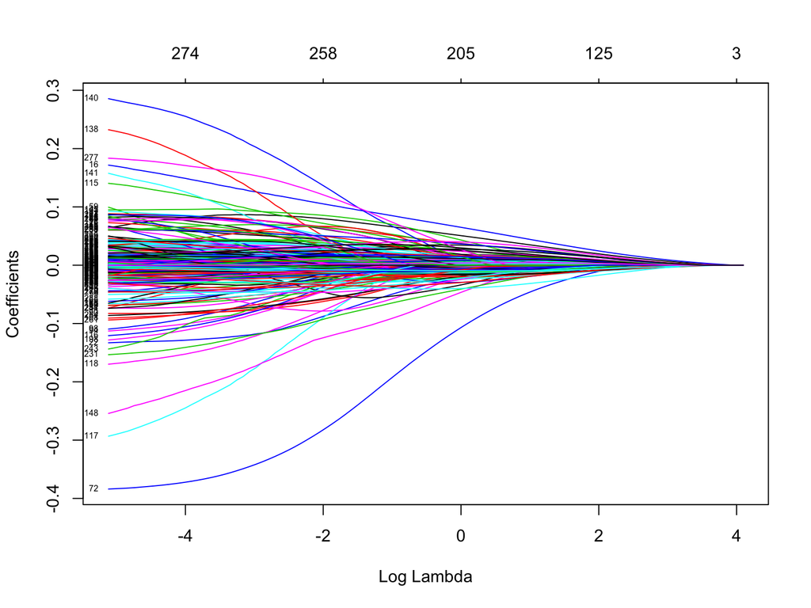

```r
set.seed(2016)
cv1=cv.glmnet(x_train,y,nfolds=10,alpha=1)
fit = glmnet(x_train, y,alpha = cv1$lambda.min)
plot(fit, xvar = "lambda", label = TRUE)
```

```r
#plot(fit, xvar = "dev", label = TRUE)
# coef(cv1)[coef(cv1)!=0]
predicted_values1 <- exp(predict(cv1,s=cv1$lambda.min,newx=x_test))
```

## Create Submission File

Ensemble the predictions from Stepwise Regression and LASSO to get final predictions.

```r
# Predict on test set and fixed some outliers
summary(predicted_values1)
```

```
##        1
##  Min.   : 44301
##  1st Qu.:127207
##  Median :158576
##  Mean   :178380
##  3rd Qu.:208815
##  Max.   :913373
```

```r
summary(sung.predicted_values)
```

```
##    Min. 1st Qu.  Median    Mean 3rd Qu.    Max.
##   48320  125700  158100  179000  210700 1623000
```

```r
predicted_values1[661] <- sung.predicted_values[661]
sung.predicted_values[1090] <- predicted_values1[1090]
predicted_values <- (sung.predicted_values + predicted_values1)/2

# Create file for submission
submission_matrix <- data.frame(cbind(house_prices_data_test$Id, predicted_values))
colnames(submission_matrix) = c('Id', 'SalePrice')
submission_matrix$SalePrice <- round(submission_matrix$SalePrice)
#submission_matrix$SalePrice <- pmax(100, submission_matrix$SalePrice)

# Write submission file
write.csv(submission_matrix, file='submission_file.csv', row.names = FALSE)
```